# small_system

## Small system

We import the necessary packages to the Jupyter notebook:

```python
import matplotlib.pyplot as plt
import numpy as np
import pandas as pd
import emachine as EM
```

```python
np.random.seed(0)
```

### Weak interactions, and large sample size

We first consider a small system with `n_var` variables (e.g, n_var = 20) which interact each other with weak interactions (e.g., interaction variance parameter `g=0.5`), and in the limit of large sample size.

```python
n_var = 20
g = 0.5
n_seq = 800
```

The synthetic data are generated by using `generate_seq`.

```python
w_true,seqs = EM.generate_seq(n_var,n_seq,g=g)
```

For convenience and to reduce computing time (in python), we use Einstein convention to convert linear and quadratic terms: $\{ops\} = \{\sigma_i, \sigma_i \sigma_j\}$ (with $i < j$). So that, `ops` is a matrix of `n_seq` x `n_var + 0.5*n_var*(n_var-1)`.

```python
ops = EM.operators(seqs)
```

We now reconstruct the interactions from the sequences `seqs` (or `ops`).

```python
# Epsilon Machine (EM)
eps_list = np.linspace(0.4,0.9,21)
E_eps = np.zeros(len(eps_list))
w_eps = np.zeros((len(eps_list),ops.shape[1]))
for i,eps in enumerate(eps_list):
    w_eps[i,:],E_eps[i] = EM.fit(ops,eps=eps,max_iter=100)
    #print(eps,E_eps[i])
ieps = np.argmax(E_eps)
print('The optimal value of eps:',eps_list[ieps])

w_em = w_eps[ieps]
```

```
The optimal value of eps: 0.75
```

```python
# Hopfield approximation (HF)
w_hf = EM.hopfield_method(seqs)

# Maximum Likelihood Estimation (MLE)
w_mle = EM.MLE_method(seqs)

# Pseudo Likelihood Estimation (PLE)
w_ple = EM.PLE_method(seqs)
```

We compare the performance of these methods.

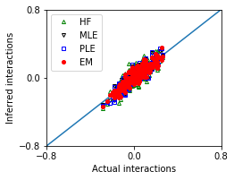

```python
nx,ny = 1,1
fig, ax = plt.subplots(ny,nx,figsize=(nx*3.5,ny*2.8))

ax.plot([-1,1],[-1,1])
ax.plot(w_true,w_hf,'g^',marker='^',mfc='none',markersize=4,label='HF')
ax.plot(w_true,w_mle,'kv',marker='v',mfc='none',markersize=4,label='MLE')
ax.plot(w_true,w_ple,'bs',marker='s',mfc='none',markersize=4,label='PLE')
ax.plot(w_true,w_em,'ro',marker='o',markersize=4,label='EM')
ax.set_xlim([-0.8,0.8])
ax.set_ylim([-0.8,0.8])
ax.set_xticks([-0.8,0,0.8])
ax.set_yticks([-0.8,0,0.8])
ax.set_xlabel('Actual interactions')
ax.set_ylabel('Inferred interactions')

ax.legend()
```

Mean squared error between actuall and inferred interactions of these methods:

```python
MSE_em = ((w_true - w_em)**2).mean()
MSE_hf = ((w_true - w_hf)**2).mean()
MSE_mle = ((w_true - w_mle)**2).mean()
MSE_ple = ((w_true - w_ple)**2).mean()

df = pd.DataFrame([['EM',MSE_em],['HF',MSE_hf],['MLE',MSE_mle],['PLE',MSE_ple]],
                  columns = ['Method','Mean squared error'])
df
```

|  | Method | Mean squared error |
| --- | --- | --- |
| 0 | EM | 0.002628 |
| 1 | HF | 0.004474 |
| 2 | MLE | 0.002442 |
| 3 | PLE | 0.002715 |

### Weak interactions, and small sample size

```python
n_var = 20
g = 0.5
n_seq = 200
```

```python
w_true,seqs = EM.generate_seq(n_var,n_seq,g=g)
```

```python
ops = EM.operators(seqs)
eps_list = np.linspace(0.4,0.9,21)
E_eps = np.zeros(len(eps_list))
w_eps = np.zeros((len(eps_list),ops.shape[1]))
for i,eps in enumerate(eps_list):
    w_eps[i,:],E_eps[i] = EM.fit(ops,eps=eps,max_iter=100)
    #print(eps,E_eps[i])
ieps = np.argmax(E_eps)
print('The optimal value of eps:',eps_list[ieps])

w_em = w_eps[ieps]

w_hf = EM.hopfield_method(seqs)
w_mle = EM.MLE_method(seqs)
w_ple = EM.PLE_method(seqs)
```

```
The optimal value of eps: 0.775
```

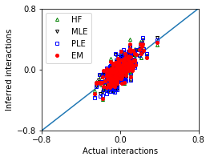

```python
nx,ny = 1,1
fig, ax = plt.subplots(ny,nx,figsize=(nx*3.5,ny*2.8))

ax.plot([-1,1],[-1,1])
ax.plot(w_true,w_hf,'g^',marker='^',mfc='none',markersize=4,label='HF')
ax.plot(w_true,w_mle,'kv',marker='v',mfc='none',markersize=4,label='MLE')
ax.plot(w_true,w_ple,'bs',marker='s',mfc='none',markersize=4,label='PLE')
ax.plot(w_true,w_em,'ro',marker='o',markersize=4,label='EM')
ax.set_xlim([-0.8,0.8])
ax.set_ylim([-0.8,0.8])
ax.set_xticks([-0.8,0,0.8])
ax.set_yticks([-0.8,0,0.8])
ax.set_xlabel('Actual interactions')
ax.set_ylabel('Inferred interactions')

ax.legend()
```

```python
MSE_em = ((w_true - w_em)**2).mean()
MSE_hf = ((w_true - w_hf)**2).mean()
MSE_mle = ((w_true - w_mle)**2).mean()
MSE_ple = ((w_true - w_ple)**2).mean()

df = pd.DataFrame([['EM',MSE_em],['HF',MSE_hf],['MLE',MSE_mle],['PLE',MSE_ple]],
                  columns = ['Method','Mean squared error'])
df
```

|  | Method | Mean squared error |
| --- | --- | --- |
| 0 | EM | 0.007569 |
| 1 | HF | 0.008781 |
| 2 | MLE | 0.008984 |
| 3 | PLE | 0.011128 |

### Strong interactions and large sample size

```python
n_var = 20
g = 1.0
n_seq = 1000
```

```python
w_true,seqs = EM.generate_seq(n_var,n_seq,g=g)
```

```python
ops = EM.operators(seqs)
eps_list = np.linspace(0.4,0.9,21)
E_eps = np.zeros(len(eps_list))
w_eps = np.zeros((len(eps_list),ops.shape[1]))
for i,eps in enumerate(eps_list):
    w_eps[i,:],E_eps[i] = EM.fit(ops,eps=eps,max_iter=100)
    #print(eps,E_eps[i])
ieps = np.argmax(E_eps)
print('The optimal value of eps:',eps_list[ieps])

w_em = w_eps[ieps]

w_hf = EM.hopfield_method(seqs)
w_mle = EM.MLE_method(seqs)
w_ple = EM.PLE_method(seqs)
```

```
The optimal value of eps: 0.65
```

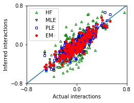

```python
nx,ny = 1,1
fig, ax = plt.subplots(ny,nx,figsize=(nx*3.5,ny*2.8))

ax.plot([-1,1],[-1,1])
ax.plot(w_true,w_hf,'g^',marker='^',mfc='none',markersize=4,label='HF')
ax.plot(w_true,w_mle,'kv',marker='v',mfc='none',markersize=4,label='MLE')
ax.plot(w_true,w_ple,'bs',marker='s',mfc='none',markersize=4,label='PLE')
ax.plot(w_true,w_em,'ro',marker='o',markersize=4,label='EM')
ax.set_xlim([-0.8,0.8])
ax.set_ylim([-0.8,0.8])
ax.set_xticks([-0.8,0,0.8])
ax.set_yticks([-0.8,0,0.8])
ax.set_xlabel('Actual interactions')
ax.set_ylabel('Inferred interactions')

ax.legend()
```

```python
MSE_em = ((w_true - w_em)**2).mean()
MSE_hf = ((w_true - w_hf)**2).mean()
MSE_mle = ((w_true - w_mle)**2).mean()
MSE_ple = ((w_true - w_ple)**2).mean()

df = pd.DataFrame([['EM',MSE_em],['HF',MSE_hf],['MLE',MSE_mle],['PLE',MSE_ple]],
                  columns = ['Method','Mean squared error'])
df
```

|  | Method | Mean squared error |
| --- | --- | --- |
| 0 | EM | 0.008664 |
| 1 | HF | 0.041372 |
| 2 | MLE | 0.010525 |
| 3 | PLE | 0.008515 |

### Strong interactions and small sample size

```python
n_var = 20
g = 1.0
n_seq = 200
```

```python
w_true,seqs = EM.generate_seq(n_var,n_seq,g=g)
```

```python
ops = EM.operators(seqs)
eps_list = np.linspace(0.4,0.9,21)
E_eps = np.zeros(len(eps_list))
w_eps = np.zeros((len(eps_list),ops.shape[1]))
for i,eps in enumerate(eps_list):
    w_eps[i,:],E_eps[i] = EM.fit(ops,eps=eps,max_iter=100)
    #print(eps,E_eps[i])
ieps = np.argmax(E_eps)
print('The optimal value of eps:',eps_list[ieps])

w_em = w_eps[ieps]

w_hf = EM.hopfield_method(seqs)
w_mle = EM.MLE_method(seqs)
w_ple = EM.PLE_method(seqs)
```

```
The optimal value of eps: 0.7250000000000001
```

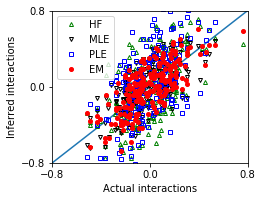

```python
nx,ny = 1,1
fig, ax = plt.subplots(ny,nx,figsize=(nx*3.5,ny*2.8))

ax.plot([-1,1],[-1,1])
ax.plot(w_true,w_hf,'g^',marker='^',mfc='none',markersize=4,label='HF')
ax.plot(w_true,w_mle,'kv',marker='v',mfc='none',markersize=4,label='MLE')
ax.plot(w_true,w_ple,'bs',marker='s',mfc='none',markersize=4,label='PLE')
ax.plot(w_true,w_em,'ro',marker='o',markersize=4,label='EM')
ax.set_xlim([-0.8,0.8])
ax.set_ylim([-0.8,0.8])
ax.set_xticks([-0.8,0,0.8])
ax.set_yticks([-0.8,0,0.8])
ax.set_xlabel('Actual interactions')
ax.set_ylabel('Inferred interactions')

ax.legend()
```

```python
MSE_em = ((w_true - w_em)**2).mean()
MSE_hf = ((w_true - w_hf)**2).mean()
MSE_mle = ((w_true - w_mle)**2).mean()
MSE_ple = ((w_true - w_ple)**2).mean()

df = pd.DataFrame([['EM',MSE_em],['HF',MSE_hf],['MLE',MSE_mle],['PLE',MSE_ple]],
                  columns = ['Method','Mean squared error'])
df
```

|  | Method | Mean squared error |
| --- | --- | --- |
| 0 | EM | 0.029413 |
| 1 | HF | 0.079308 |
| 2 | MLE | 0.034116 |
| 3 | PLE | 0.095591 |